```python
# mounting the drive
from google.colab import drive
drive.mount('/content/drive')
```

```python
import pandas as pd
import seaborn as sns
import matplotlib.pyplot as plt
import numpy as np
import tensorflow as tf
from tensorflow.keras.models import Sequential
from tensorflow.keras.layers import Conv1D, MaxPooling1D, Flatten, Dense, Dropout
from sklearn.linear_model import LogisticRegression
from sklearn.model_selection import train_test_split
from sklearn.metrics import accuracy_score, roc_auc_score
```

# Q1: Exploring Data Distribution and Relationships

1. Compute and visualize the correlation matrix for TF1, TF2, DNase accessibility, and H3K27ac using a heatmap.
2. Interpret the correlation values:
- Which features are strongly correlated? TF1 and DNase_accessibility show the highest positive correlation, while TF1 and TF2 also exhibit a moderate positive correlation. The rest of the correlations are weaker but still hint at some interdependencies.
- Do TF1 and TF2 tend to co-bind? Yes, their moderate positive correlation of 0.54 suggests that TF1 and TF2 frequently occupy the same regulatory regions
- How do accessiblity and histone modifications relate to TF binding? TF1 has a strong association with open chromatin meaning it often binds in accessible regions, TF2 shows a moderate correlation with both DNase accessibility and H3K27ac, suggesting its binding depends on both open chromatin and active enhancer marks.

### How do these relationships impact predictive modeling?

Some features such as TF1 and DNase_accessibility are closely linked, therefore models should account for potential multicollinearity and non-linear interactions...this can affect feature importance and choice of modeling approach.

### Based on correlations, would logistic regression or deep learning perform better? Why?

Deep learning models like CNNs typically handle non-linear interactions and spatial sequence patterns better than logistic regression. While logistic regression can work for simplear, linear relationships, CNNs are more adept at capturing the complex dependencies seen in genomic data.

```
Index(['DNA_sequence', 'TF1', 'TF2', 'DNase_accessibility', 'H3K27ac'], dtype='object')
                                        DNA_sequence  TF1  TF2  \
0  GATTACGAGATACAAATATATATCCAATTTCTACTAGCAATTATAA...    1    0
1  CTACGAATTGCGATGCATATTTAATAGAAAATGTATACATTTTGCT...    0    0
2  AAAAAATTAATTGAACAGCGTTTAAAATCTATGGGGTCTTGAGGCA...    0    0
3  TAGGTTGTCCCAGCCTTTAACTGTTCTCTATTGATGTTTATGTTTG...    0    0
4  ATTCAACTTTTACTAATCACTGGTTAGGTCTTATTCTGCGTTGTAC...    0    0

   DNase_accessibility  H3K27ac
0                    1        0
1                    0        0
2                    0        0
3                    0        0
4                    0        0
Correlation Matrix:
                           TF1       TF2  DNase_accessibility   H3K27ac
TF1                  1.000000  0.542462             0.771448 -0.211716
TF2                  0.542462  1.000000             0.416693  0.350957
DNase_accessibility  0.771448  0.416693             1.000000 -0.159599
H3K27ac             -0.211716  0.350957            -0.159599  1.000000
```

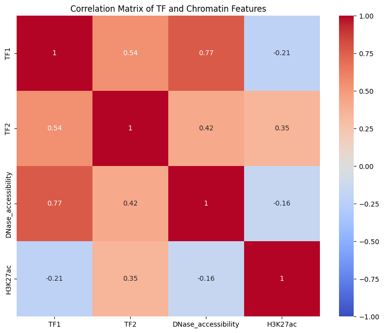

```python
df = pd.read_csv("/content/drive/MyDrive/QBIO465/tf_accessibility_modification.tsv", sep="\t")
print(df.columns)
print(df.head())

features = ['TF1', 'TF2', 'DNase_accessibility', 'H3K27ac']
correlation_matrix = df[features].corr()
print("Correlation Matrix:\n", correlation_matrix)


plt.figure(figsize=(10, 8))
sns.heatmap(correlation_matrix, annot=True, cmap='coolwarm', vmin=-1, vmax=1)
plt.title("Correlation Matrix of TF and Chromatin Features")
plt.show()
```

# Q2: Logistic Regression for TF Binding and Chromatin Accessibility

Train logistic regression models to predict TF binding and chromatin accessibility

1. Preprocessing:
- Convert DNA sequences into 1-mer one-hot encoding feature vectors
- Perform train-test splitting (80-20%) with stratification
2. Model Training:
- Train separate logistic regression models for TF1, TF2, DNase accessibility, and H3K27ac.
3. Performance Evaliuation:
- Compute accuracy and AUC (ROC-AUC) for each model

### Discuss:

- Which labels are easiest/hardest to classify? H3K27ac has the highest accuracy of 0.777 but the lowest AUC of 0.479, suggesting that while the model might be correctly predicting the majority class, it lacks discriminative power...this might be due to class imbalance. TF1 and TF2 show lower accuracy of ~0.556 and medium AUCs of ~0.550-0.599 indicating these might be more challenging to classify reliably.
- How does feature correlation (from Q1) impact performance? The moderate to strong correlations among TF binding and chromatin accessibility features can aid a linear model by emphasizing linear dependencies, but they can also lead to multicollinearity that might destabilize coefficient estimates and limit interpretability.
- What are the limitations of logistic regression for this task? Logistic regression only captures linear relationships and ignores spatial context inherent in DNA sequences. As a result, it may fail to model the complex, non-linear interactions and motif patterns that are critical for accurately predicting TF binding and chromatin accessiblity.

```python
def one_hot_encode(seq):
  mapping = {'A': [1, 0, 0, 0], 'C': [0, 1, 0, 0], 'G': [0, 0, 1, 0], 'T': [0, 0, 0, 1]}
  return np.array([mapping[base] for base in seq]).flatten()

X = np.array([one_hot_encode(s) for s in df['DNA_sequence']])

labels = ['TF1', 'TF2', 'DNase_accessibility', 'H3K27ac']
results = {}

for label in labels:
  y = df[label]
  # Stratified split
  X_train, X_test, y_train, y_test = train_test_split(
      X, y, test_size=0.2, stratify=y, random_state=42
  )
  model = LogisticRegression(max_iter=1000)
  model.fit(X_train, y_train)
  y_pred = model.predict(X_test)
  y_prob = model.predict_proba(X_test)[:, 1]
  accuracy = accuracy_score(y_test, y_pred)
  auc = roc_auc_score(y_test, y_prob)
  results[label] = {'accuracy': accuracy, 'auc': auc}
  print(f"{label}: accuracy = {accuracy:.3f}, AUC = {auc:.3f}")

#print(results)
print("\nSummary of Logistic Regression Performance:")
for label, metrics in results.items():
  print(f"{label}: Accuracy={metrics['accuracy']:.3f}, AUC={metrics['auc']:.3f}")
```

```
TF1: accuracy = 0.556, AUC = 0.550
TF2: accuracy = 0.565, AUC = 0.599
DNase_accessibility: accuracy = 0.605, AUC = 0.536
H3K27ac: accuracy = 0.777, AUC = 0.479

Summary of Logistic Regression Performance:
TF1: Accuracy=0.556, AUC=0.550
TF2: Accuracy=0.565, AUC=0.599
DNase_accessibility: Accuracy=0.605, AUC=0.536
H3K27ac: Accuracy=0.777, AUC=0.479
```

# Q3: Effect of Hyperparameter Tuning on CNN Performance

Optimize CNN performance through hyperparameter tuning, ensuring the model is trained well and avoiding overfitting.

1. Hyperparameter selection:
- Choose a suitable CNN architecture and tune parameters (eg. filter size, dropout rate, batch size, learning rate, etc.). Select the values yourself based on experimentation.
- Apply techniques discussed to improve generalization and prevent overfitting
2. Performance Analysis:
- Train the model for 30 epochs using 80% of training data
- Plot the training and validation loss/accuracy over epochs to analyze learning behavior
- Evaluate and compare Accuracy and AUC for TF1, TF2, DNase accessibility, and H3K27ac
- Create a bar plot comparing CNN and logistic regression performance from Q2

```
90/90 - 3s - 30ms/step - accuracy: 0.5865 - loss: 0.6929 - val_accuracy: 0.6031 - val_loss: 0.6721
90/90 - 2s - 27ms/step - accuracy: 0.6146 - loss: 0.6571 - val_accuracy: 0.6187 - val_loss: 0.6618
90/90 - 2s - 23ms/step - accuracy: 0.6476 - loss: 0.6217 - val_accuracy: 0.6344 - val_loss: 0.6395
90/90 - 1s - 14ms/step - accuracy: 0.7087 - loss: 0.5635 - val_accuracy: 0.6469 - val_loss: 0.6251
90/90 - 1s - 14ms/step - accuracy: 0.7649 - loss: 0.4983 - val_accuracy: 0.6594 - val_loss: 0.6262
90/90 - 2s - 28ms/step - accuracy: 0.8194 - loss: 0.4212 - val_accuracy: 0.6313 - val_loss: 0.6550
90/90 - 1s - 14ms/step - accuracy: 0.8469 - loss: 0.3642 - val_accuracy: 0.6031 - val_loss: 0.6772
90/90 - 1s - 14ms/step - accuracy: 0.8698 - loss: 0.3176 - val_accuracy: 0.6313 - val_loss: 0.7049
90/90 - 1s - 14ms/step - accuracy: 0.8941 - loss: 0.2704 - val_accuracy: 0.6313 - val_loss: 0.7019
90/90 - 1s - 15ms/step - accuracy: 0.9128 - loss: 0.2370 - val_accuracy: 0.6438 - val_loss: 0.7267
90/90 - 2s - 21ms/step - accuracy: 0.9139 - loss: 0.2166 - val_accuracy: 0.6406 - val_loss: 0.7490
90/90 - 1s - 14ms/step - accuracy: 0.9361 - loss: 0.1817 - val_accuracy: 0.6500 - val_loss: 0.7347
90/90 - 1s - 14ms/step - accuracy: 0.9399 - loss: 0.1602 - val_accuracy: 0.6344 - val_loss: 0.7929
90/90 - 1s - 13ms/step - accuracy: 0.9413 - loss: 0.1578 - val_accuracy: 0.6344 - val_loss: 0.8683
90/90 - 1s - 14ms/step - accuracy: 0.9535 - loss: 0.1374 - val_accuracy: 0.6344 - val_loss: 0.9000
90/90 - 1s - 14ms/step - accuracy: 0.9559 - loss: 0.1298 - val_accuracy: 0.6438 - val_loss: 0.8772
90/90 - 1s - 14ms/step - accuracy: 0.9649 - loss: 0.1092 - val_accuracy: 0.6531 - val_loss: 0.8581
90/90 - 1s - 15ms/step - accuracy: 0.9469 - loss: 0.1446 - val_accuracy: 0.6281 - val_loss: 0.9313
90/90 - 2s - 20ms/step - accuracy: 0.9608 - loss: 0.1168 - val_accuracy: 0.6656 - val_loss: 0.9147
90/90 - 2s - 24ms/step - accuracy: 0.9722 - loss: 0.0889 - val_accuracy: 0.6781 - val_loss: 0.8964
90/90 - 3s - 29ms/step - accuracy: 0.9691 - loss: 0.0847 - val_accuracy: 0.6531 - val_loss: 1.0094
90/90 - 1s - 16ms/step - accuracy: 0.9726 - loss: 0.0837 - val_accuracy: 0.6625 - val_loss: 0.9073
90/90 - 3s - 28ms/step - accuracy: 0.9726 - loss: 0.0790 - val_accuracy: 0.6562 - val_loss: 1.2424
90/90 - 2s - 17ms/step - accuracy: 0.9736 - loss: 0.0745 - val_accuracy: 0.6656 - val_loss: 1.0534
90/90 - 2s - 23ms/step - accuracy: 0.9715 - loss: 0.0803 - val_accuracy: 0.6750 - val_loss: 0.9817
90/90 - 2s - 21ms/step - accuracy: 0.9778 - loss: 0.0737 - val_accuracy: 0.6812 - val_loss: 1.0428
90/90 - 2s - 17ms/step - accuracy: 0.9816 - loss: 0.0600 - val_accuracy: 0.6812 - val_loss: 1.1521
90/90 - 2s - 27ms/step - accuracy: 0.9816 - loss: 0.0623 - val_accuracy: 0.6906 - val_loss: 1.0523
90/90 - 1s - 16ms/step - accuracy: 0.9781 - loss: 0.0660 - val_accuracy: 0.6781 - val_loss: 1.0777
90/90 - 2s - 27ms/step - accuracy: 0.9774 - loss: 0.0677 - val_accuracy: 0.6875 - val_loss: 1.0172
25/25 ━━━━━━━━━━━━━━━━━━━━ 0s 8ms/step
TF1: Test Accuracy = 0.685, Test AUC = 0.740
```

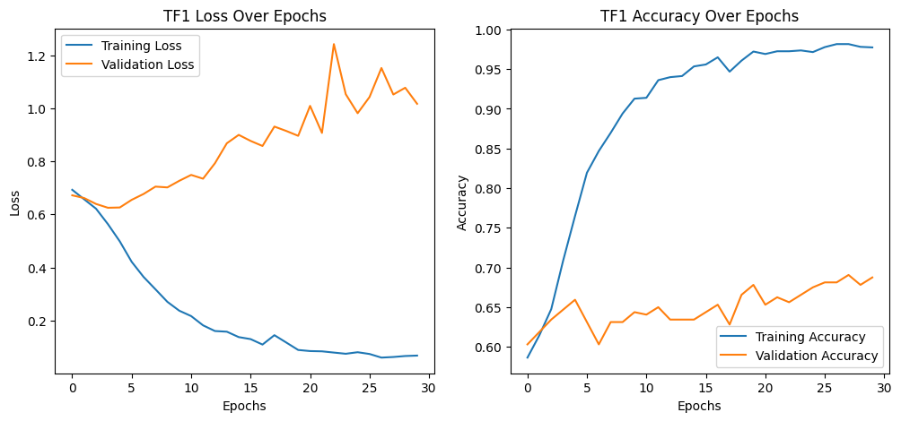

```
90/90 - 3s - 29ms/step - accuracy: 0.5181 - loss: 0.7087 - val_accuracy: 0.5188 - val_loss: 0.6901
90/90 - 2s - 27ms/step - accuracy: 0.5872 - loss: 0.6604 - val_accuracy: 0.5500 - val_loss: 0.6609
90/90 - 2s - 28ms/step - accuracy: 0.7410 - loss: 0.5388 - val_accuracy: 0.7281 - val_loss: 0.5421
90/90 - 1s - 16ms/step - accuracy: 0.8253 - loss: 0.4123 - val_accuracy: 0.7500 - val_loss: 0.4941
90/90 - 2s - 22ms/step - accuracy: 0.8757 - loss: 0.3126 - val_accuracy: 0.8344 - val_loss: 0.4381
90/90 - 2s - 20ms/step - accuracy: 0.9233 - loss: 0.2239 - val_accuracy: 0.7937 - val_loss: 0.4335
90/90 - 2s - 17ms/step - accuracy: 0.9479 - loss: 0.1640 - val_accuracy: 0.8313 - val_loss: 0.4376
90/90 - 2s - 17ms/step - accuracy: 0.9618 - loss: 0.1281 - val_accuracy: 0.8125 - val_loss: 0.4456
90/90 - 3s - 28ms/step - accuracy: 0.9694 - loss: 0.1061 - val_accuracy: 0.8125 - val_loss: 0.4529
90/90 - 2s - 17ms/step - accuracy: 0.9632 - loss: 0.1063 - val_accuracy: 0.8406 - val_loss: 0.4648
90/90 - 1s - 16ms/step - accuracy: 0.9816 - loss: 0.0702 - val_accuracy: 0.8344 - val_loss: 0.4471
90/90 - 3s - 32ms/step - accuracy: 0.9826 - loss: 0.0628 - val_accuracy: 0.8344 - val_loss: 0.4754
90/90 - 1s - 16ms/step - accuracy: 0.9851 - loss: 0.0518 - val_accuracy: 0.8438 - val_loss: 0.4875
90/90 - 3s - 29ms/step - accuracy: 0.9878 - loss: 0.0443 - val_accuracy: 0.8531 - val_loss: 0.4852
90/90 - 1s - 16ms/step - accuracy: 0.9896 - loss: 0.0406 - val_accuracy: 0.8500 - val_loss: 0.5097
90/90 - 3s - 28ms/step - accuracy: 0.9858 - loss: 0.0446 - val_accuracy: 0.8500 - val_loss: 0.4723
90/90 - 3s - 37ms/step - accuracy: 0.9896 - loss: 0.0396 - val_accuracy: 0.8531 - val_loss: 0.4616
90/90 - 2s - 19ms/step - accuracy: 0.9910 - loss: 0.0321 - val_accuracy: 0.8531 - val_loss: 0.4750
90/90 - 1s - 17ms/step - accuracy: 0.9948 - loss: 0.0231 - val_accuracy: 0.8438 - val_loss: 0.5200
90/90 - 2s - 17ms/step - accuracy: 0.9910 - loss: 0.0288 - val_accuracy: 0.8656 - val_loss: 0.4871
90/90 - 1s - 16ms/step - accuracy: 0.9937 - loss: 0.0254 - val_accuracy: 0.8562 - val_loss: 0.5669
90/90 - 2s - 17ms/step - accuracy: 0.9903 - loss: 0.0288 - val_accuracy: 0.8438 - val_loss: 0.5001
90/90 - 3s - 31ms/step - accuracy: 0.9948 - loss: 0.0218 - val_accuracy: 0.8531 - val_loss: 0.4851
90/90 - 2s - 26ms/step - accuracy: 0.9951 - loss: 0.0185 - val_accuracy: 0.8594 - val_loss: 0.5031
90/90 - 1s - 16ms/step - accuracy: 0.9962 - loss: 0.0173 - val_accuracy: 0.8687 - val_loss: 0.5474
90/90 - 3s - 29ms/step - accuracy: 0.9920 - loss: 0.0250 - val_accuracy: 0.8406 - val_loss: 0.7478
90/90 - 1s - 16ms/step - accuracy: 0.9934 - loss: 0.0209 - val_accuracy: 0.8594 - val_loss: 0.5342
90/90 - 2s - 17ms/step - accuracy: 0.9920 - loss: 0.0257 - val_accuracy: 0.8375 - val_loss: 0.5501
90/90 - 3s - 34ms/step - accuracy: 0.9955 - loss: 0.0158 - val_accuracy: 0.8719 - val_loss: 0.5577
90/90 - 2s - 22ms/step - accuracy: 0.9948 - loss: 0.0194 - val_accuracy: 0.8687 - val_loss: 0.5049
25/25 ━━━━━━━━━━━━━━━━━━━━ 0s 5ms/step
TF2: Test Accuracy = 0.856, Test AUC = 0.925
```

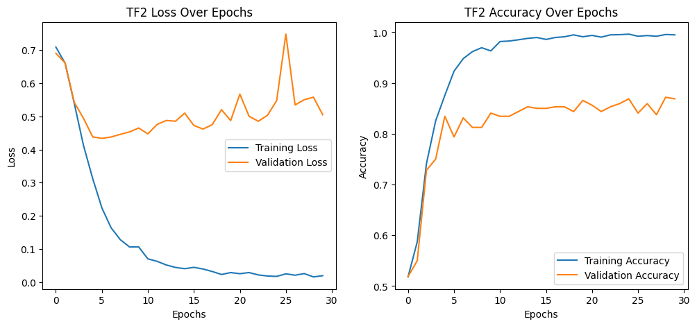

```
90/90 - 3s - 29ms/step - accuracy: 0.7139 - loss: 0.6110 - val_accuracy: 0.7188 - val_loss: 0.5918
90/90 - 2s - 26ms/step - accuracy: 0.7198 - loss: 0.5796 - val_accuracy: 0.7188 - val_loss: 0.5866
90/90 - 1s - 16ms/step - accuracy: 0.7198 - loss: 0.5400 - val_accuracy: 0.7188 - val_loss: 0.5779
90/90 - 2s - 24ms/step - accuracy: 0.7198 - loss: 0.4840 - val_accuracy: 0.7188 - val_loss: 0.5678
90/90 - 2s - 20ms/step - accuracy: 0.7663 - loss: 0.4396 - val_accuracy: 0.7188 - val_loss: 0.6172
90/90 - 3s - 30ms/step - accuracy: 0.7976 - loss: 0.3839 - val_accuracy: 0.7312 - val_loss: 0.6007
90/90 - 2s - 27ms/step - accuracy: 0.8299 - loss: 0.3595 - val_accuracy: 0.7250 - val_loss: 0.5838
90/90 - 3s - 28ms/step - accuracy: 0.8684 - loss: 0.3363 - val_accuracy: 0.7250 - val_loss: 0.6116
90/90 - 3s - 32ms/step - accuracy: 0.8875 - loss: 0.2906 - val_accuracy: 0.7281 - val_loss: 0.6364
90/90 - 2s - 24ms/step - accuracy: 0.9149 - loss: 0.2443 - val_accuracy: 0.7375 - val_loss: 0.8061
90/90 - 3s - 28ms/step - accuracy: 0.9174 - loss: 0.2365 - val_accuracy: 0.7500 - val_loss: 0.6225
90/90 - 3s - 28ms/step - accuracy: 0.9299 - loss: 0.2047 - val_accuracy: 0.7312 - val_loss: 0.8441
90/90 - 3s - 34ms/step - accuracy: 0.9458 - loss: 0.1788 - val_accuracy: 0.7219 - val_loss: 0.6902
90/90 - 2s - 20ms/step - accuracy: 0.9497 - loss: 0.1649 - val_accuracy: 0.6906 - val_loss: 0.7045
90/90 - 2s - 25ms/step - accuracy: 0.9507 - loss: 0.1581 - val_accuracy: 0.7406 - val_loss: 1.0956
90/90 - 1s - 16ms/step - accuracy: 0.9476 - loss: 0.1618 - val_accuracy: 0.7437 - val_loss: 0.7896
90/90 - 2s - 27ms/step - accuracy: 0.9559 - loss: 0.1380 - val_accuracy: 0.7312 - val_loss: 0.8481
90/90 - 3s - 29ms/step - accuracy: 0.9663 - loss: 0.1189 - val_accuracy: 0.7469 - val_loss: 0.8175
90/90 - 3s - 32ms/step - accuracy: 0.9701 - loss: 0.0998 - val_accuracy: 0.7437 - val_loss: 0.8880
90/90 - 2s - 25ms/step - accuracy: 0.9736 - loss: 0.1008 - val_accuracy: 0.7406 - val_loss: 0.8631
90/90 - 1s - 16ms/step - accuracy: 0.9674 - loss: 0.0986 - val_accuracy: 0.7437 - val_loss: 0.9809
90/90 - 2s - 27ms/step - accuracy: 0.9698 - loss: 0.1017 - val_accuracy: 0.7500 - val_loss: 1.1728
90/90 - 2s - 17ms/step - accuracy: 0.9712 - loss: 0.0960 - val_accuracy: 0.7594 - val_loss: 0.9077
90/90 - 3s - 36ms/step - accuracy: 0.9771 - loss: 0.0874 - val_accuracy: 0.7563 - val_loss: 0.8281
90/90 - 2s - 21ms/step - accuracy: 0.9740 - loss: 0.0858 - val_accuracy: 0.7656 - val_loss: 0.8497
90/90 - 2s - 17ms/step - accuracy: 0.9740 - loss: 0.0904 - val_accuracy: 0.7594 - val_loss: 1.1029
90/90 - 2s - 17ms/step - accuracy: 0.9733 - loss: 0.0829 - val_accuracy: 0.7594 - val_loss: 1.0238
90/90 - 1s - 16ms/step - accuracy: 0.9771 - loss: 0.0690 - val_accuracy: 0.7531 - val_loss: 1.1595
90/90 - 3s - 28ms/step - accuracy: 0.9826 - loss: 0.0599 - val_accuracy: 0.7594 - val_loss: 1.0421
90/90 - 2s - 19ms/step - accuracy: 0.9771 - loss: 0.0729 - val_accuracy: 0.7563 - val_loss: 1.2797
25/25 ━━━━━━━━━━━━━━━━━━━━ 0s 5ms/step
DNase_accessibility: Test Accuracy = 0.756, Test AUC = 0.714
```

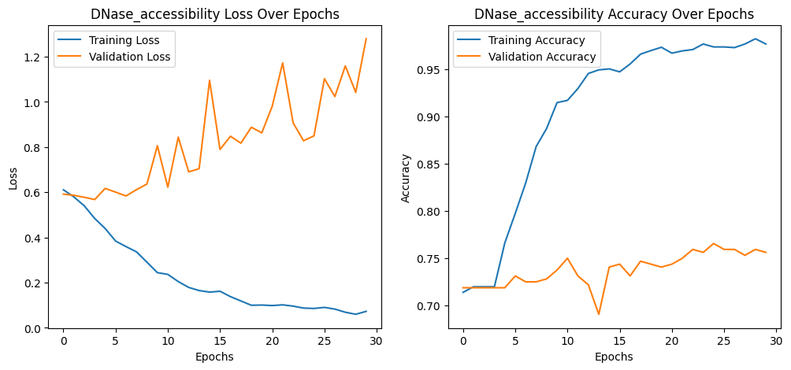

```
90/90 - 3s - 30ms/step - accuracy: 0.8670 - loss: 0.4184 - val_accuracy: 0.8844 - val_loss: 0.3994
90/90 - 1s - 17ms/step - accuracy: 0.8830 - loss: 0.3600 - val_accuracy: 0.8844 - val_loss: 0.3571
90/90 - 3s - 29ms/step - accuracy: 0.8830 - loss: 0.3275 - val_accuracy: 0.8844 - val_loss: 0.3585
90/90 - 2s - 18ms/step - accuracy: 0.8840 - loss: 0.2863 - val_accuracy: 0.8844 - val_loss: 0.3650
90/90 - 3s - 34ms/step - accuracy: 0.8938 - loss: 0.2308 - val_accuracy: 0.8813 - val_loss: 0.4014
90/90 - 2s - 22ms/step - accuracy: 0.9174 - loss: 0.1876 - val_accuracy: 0.8813 - val_loss: 0.4038
90/90 - 2s - 27ms/step - accuracy: 0.9319 - loss: 0.1498 - val_accuracy: 0.8813 - val_loss: 0.4472
90/90 - 1s - 16ms/step - accuracy: 0.9503 - loss: 0.1245 - val_accuracy: 0.8781 - val_loss: 0.4947
90/90 - 3s - 28ms/step - accuracy: 0.9698 - loss: 0.0967 - val_accuracy: 0.8687 - val_loss: 0.5150
90/90 - 3s - 37ms/step - accuracy: 0.9663 - loss: 0.0889 - val_accuracy: 0.8687 - val_loss: 0.5642
90/90 - 1s - 16ms/step - accuracy: 0.9722 - loss: 0.0806 - val_accuracy: 0.8813 - val_loss: 0.7237
90/90 - 1s - 16ms/step - accuracy: 0.9753 - loss: 0.0689 - val_accuracy: 0.8687 - val_loss: 0.7496
90/90 - 1s - 16ms/step - accuracy: 0.9851 - loss: 0.0542 - val_accuracy: 0.8594 - val_loss: 0.6696
90/90 - 1s - 16ms/step - accuracy: 0.9809 - loss: 0.0541 - val_accuracy: 0.8656 - val_loss: 0.7271
90/90 - 2s - 17ms/step - accuracy: 0.9858 - loss: 0.0456 - val_accuracy: 0.8531 - val_loss: 0.7249
90/90 - 1s - 16ms/step - accuracy: 0.9868 - loss: 0.0422 - val_accuracy: 0.8750 - val_loss: 0.8417
90/90 - 3s - 37ms/step - accuracy: 0.9826 - loss: 0.0487 - val_accuracy: 0.8813 - val_loss: 0.9249
90/90 - 2s - 17ms/step - accuracy: 0.9872 - loss: 0.0404 - val_accuracy: 0.8813 - val_loss: 0.9669
90/90 - 3s - 28ms/step - accuracy: 0.9872 - loss: 0.0359 - val_accuracy: 0.8656 - val_loss: 0.9115
90/90 - 3s - 28ms/step - accuracy: 0.9903 - loss: 0.0342 - val_accuracy: 0.8687 - val_loss: 0.8547
90/90 - 3s - 28ms/step - accuracy: 0.9920 - loss: 0.0272 - val_accuracy: 0.8656 - val_loss: 0.8877
90/90 - 3s - 34ms/step - accuracy: 0.9920 - loss: 0.0310 - val_accuracy: 0.8719 - val_loss: 1.0095
90/90 - 2s - 23ms/step - accuracy: 0.9917 - loss: 0.0295 - val_accuracy: 0.8562 - val_loss: 0.8728
90/90 - 1s - 16ms/step - accuracy: 0.9917 - loss: 0.0386 - val_accuracy: 0.8562 - val_loss: 0.9117
90/90 - 3s - 28ms/step - accuracy: 0.9924 - loss: 0.0281 - val_accuracy: 0.8687 - val_loss: 0.9763
90/90 - 1s - 16ms/step - accuracy: 0.9906 - loss: 0.0268 - val_accuracy: 0.8781 - val_loss: 1.4376
90/90 - 1s - 16ms/step - accuracy: 0.9924 - loss: 0.0282 - val_accuracy: 0.8625 - val_loss: 1.1431
90/90 - 3s - 33ms/step - accuracy: 0.9920 - loss: 0.0266 - val_accuracy: 0.8687 - val_loss: 1.2866
90/90 - 1s - 16ms/step - accuracy: 0.9892 - loss: 0.0275 - val_accuracy: 0.8719 - val_loss: 1.2910
90/90 - 3s - 28ms/step - accuracy: 0.9910 - loss: 0.0289 - val_accuracy: 0.8719 - val_loss: 1.2918
25/25 ━━━━━━━━━━━━━━━━━━━━ 0s 4ms/step
H3K27ac: Test Accuracy = 0.865, Test AUC = 0.487
```

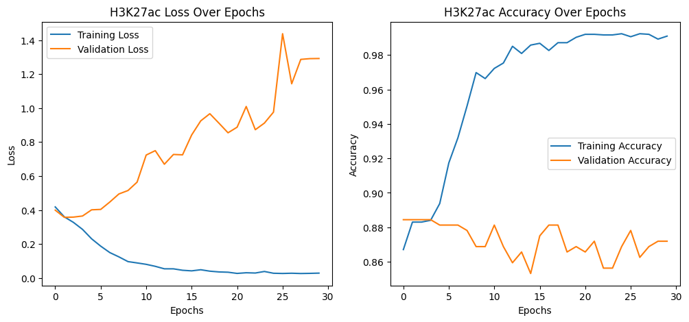

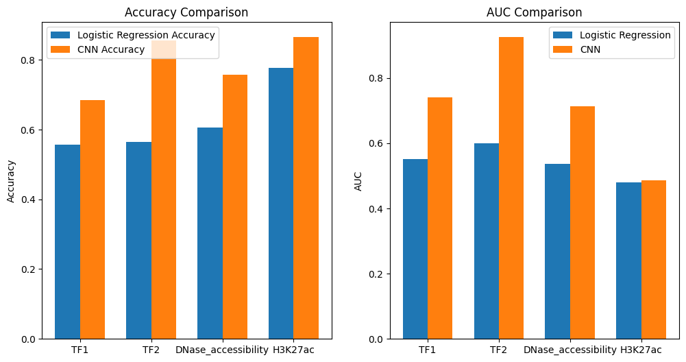

```python
max_length = max(df['DNA_sequence'].apply(len))

def one_hot_encode_matrix(seq, max_length):
  mapping = {'A': [1, 0, 0, 0], 'C': [0, 1, 0, 0], 'G': [0, 0, 1, 0], 'T': [0, 0, 0, 1]}
  encoding = np.array([mapping[base] for base in seq])
  if len(seq) < max_length:
    pad = np.zeros((max_length - len(seq), 4))
    encoding = np.vstack((encoding, pad))
  else:
    encoding = encoding[:max_length]
  return encoding

X_cnn = np.array([one_hot_encode_matrix(seq, max_length) for seq in df['DNA_sequence']])
input_shape = X_cnn.shape[1:]
labels = ['TF1', 'TF2', 'DNase_accessibility', 'H3K27ac']
cnn_results = {}

for label in labels:
  y = df[label].values
  X_train, X_test, y_train, y_test = train_test_split(
      X_cnn, y, test_size=0.2, stratify=y, random_state=42
  )
  X_train, X_val, y_train, y_val = train_test_split(
      X_train, y_train, test_size=0.1, stratify=y_train, random_state=42
  )

  # Filter size 10, 32 filters, dropout rate 0.3, learning rate 0.001
  model = Sequential([
      Conv1D(filters=32, kernel_size=10, activation='relu', input_shape=input_shape),
      MaxPooling1D(pool_size=2),
      Dropout(0.3),
      Flatten(),
      Dense(64, activation='relu'),
      Dropout(0.3),
      Dense(1, activation='sigmoid')
  ])
  model.compile(optimizer=tf.keras.optimizers.Adam(learning_rate=0.001), loss='binary_crossentropy', metrics=['accuracy'])
  history = model.fit(X_train, y_train, epochs=30, batch_size=32, validation_data=(X_val, y_val), verbose=2)
  test_loss, test_acc = model.evaluate(X_test, y_test, verbose=0)
  y_prob = model.predict(X_test).flatten()
  test_auc = roc_auc_score(y_test, y_prob)
  cnn_results[label] = {'accuracy': test_acc, 'auc': test_auc}
  print(f"{label}: Test Accuracy = {test_acc:.3f}, Test AUC = {test_auc:.3f}")

  # Plotting training history: Loss and Accuracy over epochs
  plt.figure(figsize=(12, 5))
  plt.subplot(1, 2, 1)
  plt.plot(history.history['loss'], label='Training Loss')
  plt.plot(history.history['val_loss'], label='Validation Loss')
  plt.title(f'{label} Loss Over Epochs')
  plt.xlabel('Epochs')
  plt.ylabel('Loss')
  plt.legend()

  plt.subplot(1,2,2)
  plt.plot(history.history['accuracy'], label='Training Accuracy')
  plt.plot(history.history['val_accuracy'], label='Validation Accuracy')
  plt.title(f'{label} Accuracy Over Epochs')
  plt.xlabel('Epochs')
  plt.ylabel('Accuracy')
  plt.legend()

  plt.show()

# Bar plot for comparing CNN and logistic regression performance for each label
labels_list = labels
lr_accuracy = [results[label]['accuracy'] for label in labels_list]
lr_auc = [results[label]['auc'] for label in labels_list]
cnn_accuracy = [cnn_results[label]['accuracy'] for label in labels_list]
cnn_auc = [cnn_results[label]['auc'] for label in labels_list]

x = np.arange(len(labels_list))
width = 0.35

plt.figure(figsize=(12,6))
plt.subplot(1,2,1)
plt.bar(x - width/2, lr_accuracy, width, label='Logistic Regression Accuracy')
plt.bar(x + width/2, cnn_accuracy, width, label='CNN Accuracy')
plt.xticks(x, labels_list)
plt.ylabel('Accuracy')
plt.title('Accuracy Comparison')
plt.legend()

plt.subplot(1,2,2)
plt.bar(x - width/2, lr_auc, width, label='Logistic Regression')
plt.bar(x + width/2, cnn_auc, width, label='CNN')
plt.xticks(x, labels_list)
plt.ylabel('AUC')
plt.title('AUC Comparison')
plt.legend()
plt.show()
```

```python
#!pip install
!jupyter nbconvert --to html "/content/drive/MyDrive/QBIO465/SEB QBIO465 HW4.ipynb"
```

[output not shown]

[output cut: 136 more lines]

[output not shown]